# gabceline’s nyc cafe reviews

gabriella carlos

2024-12-29

## introduction

i enjoy coffee and matcha and spend more than i should buying it outside or making it at home. as an engineering college student in nyc, i rely on caffeine and a good study space. to make the most of my visits, i’ve put together a set of metrics to evaluate what makes a café good or bad. this will be continuously updated!

## overall rankings

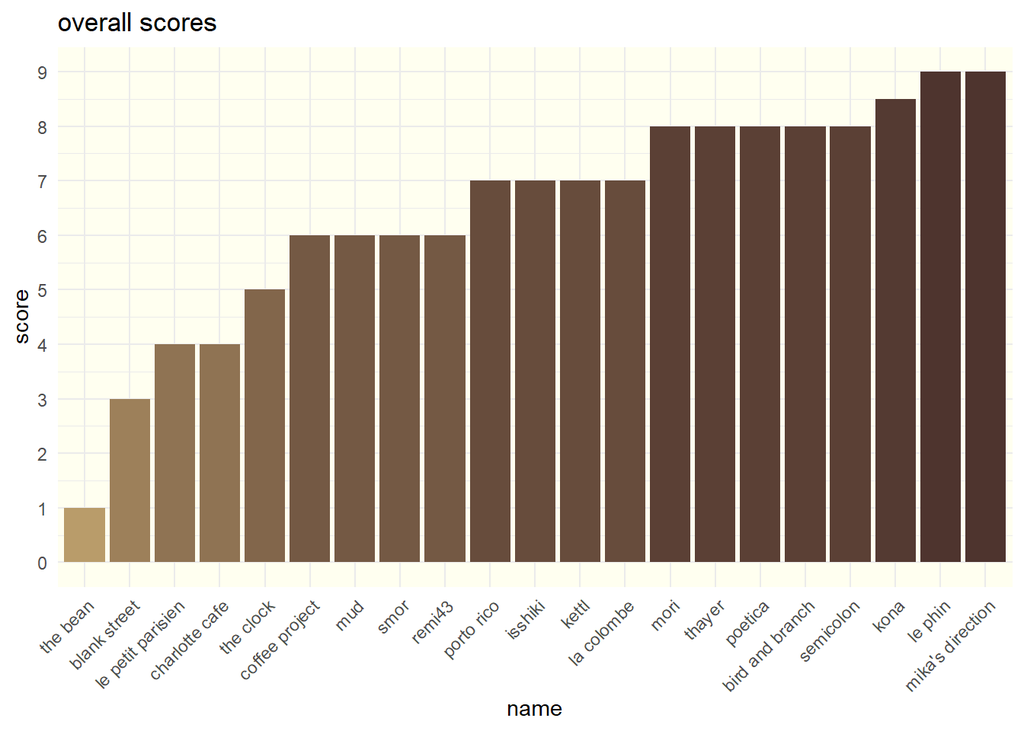

### notes

1. the bean: overpriced, every barista is mean, bad quality
2. blank street: its hit or miss to be honest. i like the ideas they have for drinks, but never the execution
3. le petit parisien: a cooper union classic. the older gentleman who works there is so sweet, but the coffee is perpetually bitter.
4. charlotte cafe: fine. just fine.
5. the clock: this is in the lobby of 22 vanderbilt, so its quite beautiful. coffee was fine and a bit small but it suffices
6. coffee project: one of the many coffee shops with asian flavors in nyc. i find their stuff too sweet and other places just do it better
7. mud: popular brunch spot. maple latte is so good, but expensive
8. smor: stereotypical east village coffee shop
9. remi43: combo flower shop and cafe. incredibly beautiful orchids. menu was quite regular
10. porto rico: they know what theyre doing here! good for on the go coffee, if you have time to spare in a line
11. isshiki: omakase by night, cafe by day. solid matcha option
12. kettl: great tea varieties
13. mori: the garden in the back of this cafe really gives this place a lot of points. nothing too special on the menu, but theyre quite new so ill let them off the hook for that
14. thayer: such a beautiful interior, crazy nice owner. minimalist menu, sparkling water on tap makes up for it
15. poetica: reliable iced latte, plethora of flavors. a beautiful spectacle
16. bird and branch: biased because izzy works here. one of the places that do asian flavors and creative drinks right 16: kona: the hawaiian latte is really amazing… i think about it many times a day
17. le phin: vietnamese cafe. dare i say, the best asian cafe in new york. everything i get there is simply delicious
18. mika’s direction: the best matcha i have had in nyc so far. the owner (THE mika) is from japan and makes sure you like your drink. really sweet experience
19. la colombe: good draft lattes, so expensive though. pretty busy due to proximity to NYU, but at least you can see a B list celebrity 30% of the time. nice to do work (not studying.) when you can find a seat
20. semicolon: very creative matcha lattes! spacious interior, with a loft :D

## price

#### for a small, hot latte as of december 2024

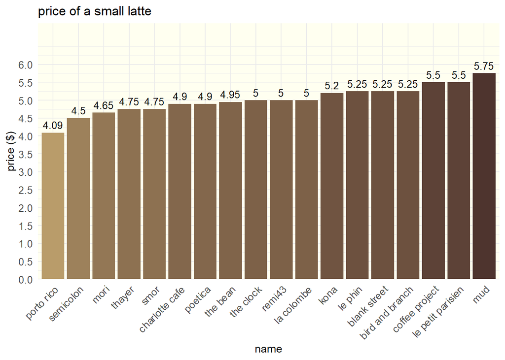

*note: on wednesdays after noon, poetica has 50% off everything which makes it a pretty unbeatable deal.*

## workability

this is my measure of how well i can study or do homework in the cafe. 0 is unworkable and 10 is ideal. it depends on the amount of seating, square footage, outlet availability, and demand.

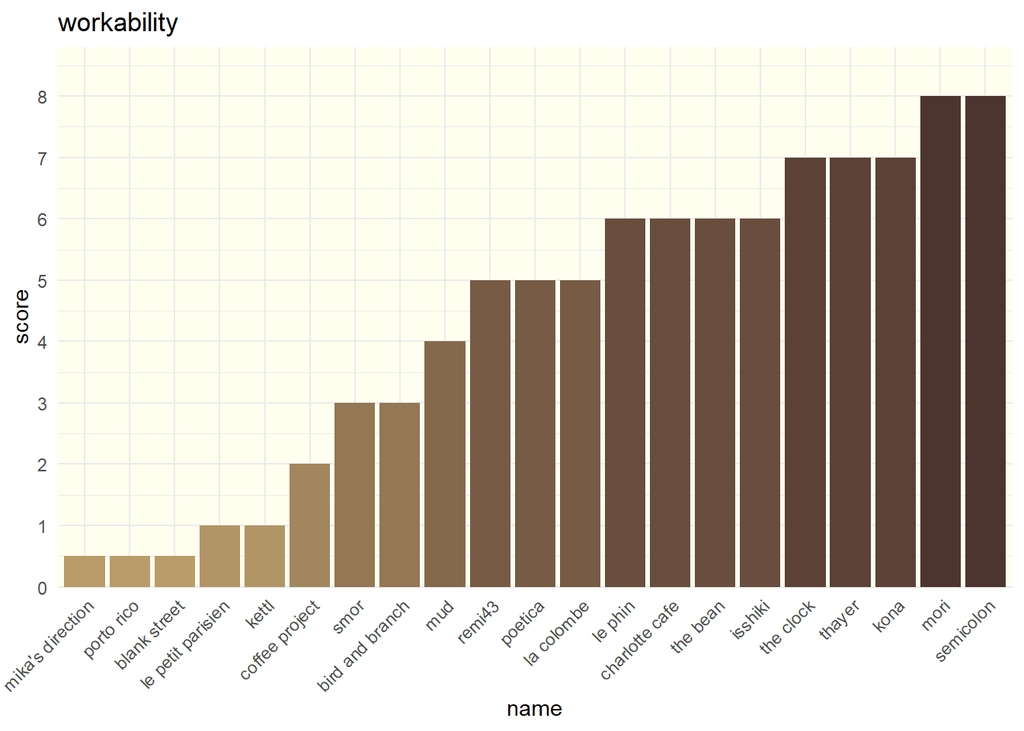

## matcha latte color test

my general rule of thumb is that the darker and more vibrant the green of my matcha latte is, the richer the taste. i prefer a very robust but not bitter taste, only achievable with quality matcha powders.

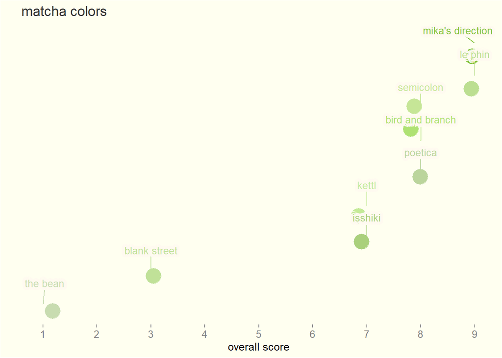

*this is only for matcha lattes made by the cafe barista, not purchased matcha powder and made at home. if you’re interested, check out me and izzy’s comparative analysis of caffeine and l-theanine content in 4 different matcha brands using hplc!*